# Direct human pressure on the Gulf coast

This notebook turns the 2020 population grid into a coastal pressure for the Gulf of California.

It follows the global direct-human method used for Cumulative Human Impacts. Each cell is scored by how many people live within 10 km. That count is logged, because additional people add less impact once a shore is already crowded. The score is then kept on a narrow strip of shore: 1 km inland and 1 km offshore. Inside that strip, the 99.9th percentile is the top of the scale. Every cell is divided by that Gulf value, and anything higher is set to 1.

The global analysis used only the offshore side of the shore, and it scaled to a worldwide percentile. Here both sides of the shore are kept, and the percentile is taken inside the Gulf.

Two files are written to `output/`:

- `direct_human_2020_rescaled.tif` — the 0–1 pressure on the shore strip
- `direct_human_pressure.csv` — mean pressure in each OHI region (`rgn_id`, `year`, `pressure`)

```r
library(terra)
library(sf)
library(dplyr)
library(readr)
library(knitr)
```

```r
knitr::opts_chunk$set(fig.width = 8, fig.height = 7, message = FALSE, warning = FALSE)

pop_path <- "/home/shares/ohi/OHI_GOC/goal_prep/pressures/population_rasters/pop_2020.tif"
rgn_path <- "/home/shares/ohi/OHI_GOC/spatial/OHI_regions/goc_ohi_rgns.shp"
coast_path <- "/home/shares/ohi/OHI_GOC/spatial/OHI_regions/goc_coastline.gpkg"

out_dir <- "/home/frazier/ohi_goc_prep/_pressures/prs_population/output"
dir.create(out_dir, showWarnings = FALSE)

# Window of people around each cell, and the shore strip used for the score.
radius_m <- 10000
shore_m <- 1000
quantile_p <- 0.999
year <- 2020
```

## 1. Population in 2020

Each cell is 1 km by 1 km. The value is the number of people placed in that cell from the INEGI 2020 locality census. Empty cells are 0.

```r
pop <- rast(pop_path)
pop <- ifel(is.na(pop), 0, pop)
names(pop) <- "people"

# Display only. Zeros are hidden so the towns are visible. The raster used below still has those zeros.
pop_for_plot <- ifel(pop == 0, NA, pop)

global(pop, "sum", na.rm = TRUE)
```

```
##             sum
## people 13550167
```

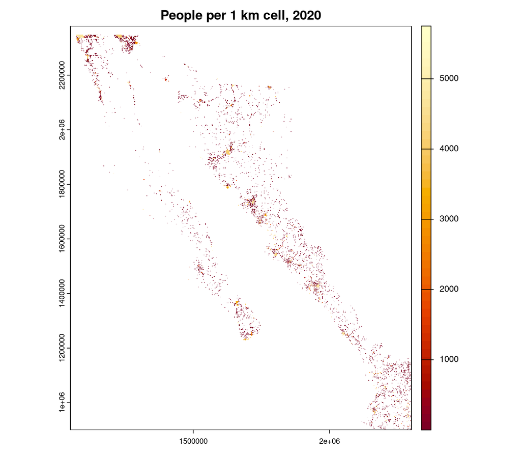

```r
plot(pop_for_plot, main = "People per 1 km cell, 2020", col = hcl.colors(50, "YlOrRd"))
```

## 2. People within 10 km

For every cell, add up the people in a circle of radius 10 km.

A circle of weights from `focalMat()` sums to 1, so feeding those weights to `focal()` would return an average per cell. The pressure used here is the count of people, so each cell inside the circle is given weight 1.

```r
weights <- focalMat(pop, radius_m, type = "circle")
count_window <- matrix(as.integer(weights > 0), nrow = nrow(weights))

people_10km <- focal(pop, w = count_window, fun = "sum", na.rm = TRUE)
names(people_10km) <- "people_within_10km"

summary(values(people_10km))
```

```
##  people_within_10km
##  Min.   :      0
##  1st Qu.:      0
##  Median :      0
##  Mean   :   2318
##  3rd Qu.:      0
##  Max.   :1097461
```

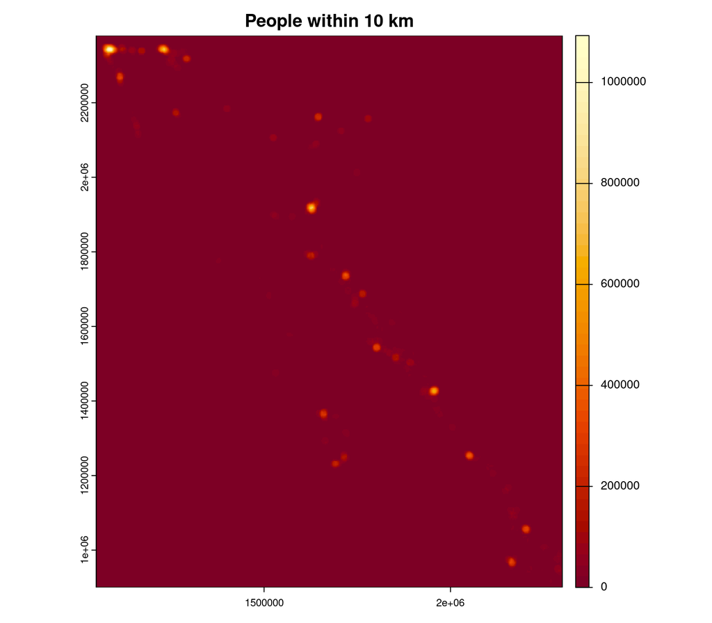

```r
plot(people_10km, main = "People within 10 km", col = hcl.colors(50, "YlOrRd"))
```

## 3. Log the counts

`log(people + 1)` leaves empty areas at 0 and shrinks the gap between a town and a city. One person added to an empty shore still registers. One person added to a city barely moves the score.

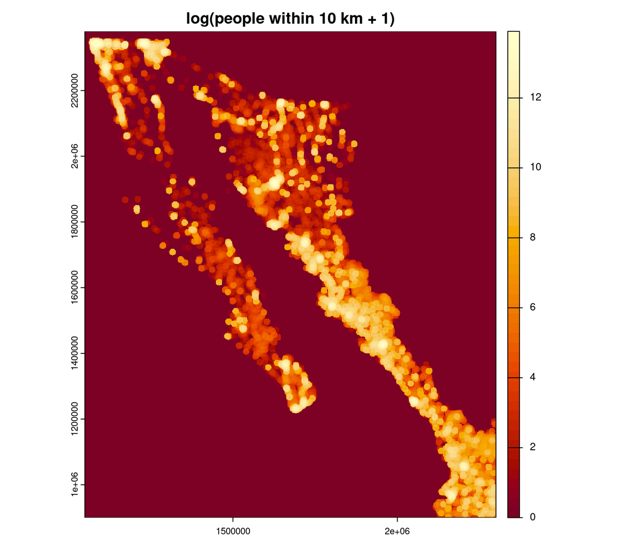

```r
log_people <- log1p(people_10km)
names(log_people) <- "log_people_10km"

plot(log_people, main = "log(people within 10 km + 1)", col = hcl.colors(50, "YlOrRd"))
```

## 4. Keep 1 km of shore, on both sides

The coastline is the Gulf shore, including islands. A 1 km buffer of that line is cut by the OHI regions.

- The piece that falls in a **land** region is the inland side.
- The piece that falls in a **marine** region is the offshore side.

Cells outside this strip are dropped. Open water is not given a pressure of zero, because a later average would treat that water as unaffected coast.

```r
regions <- st_read(rgn_path, quiet = TRUE) %>%
  st_transform(crs(pop)) %>%
  st_make_valid()

coast <- st_read(coast_path, quiet = TRUE) %>%
  st_transform(crs(pop))

shore_band <- st_buffer(st_union(st_geometry(coast)), shore_m) %>%
  st_make_valid()

# Keep polygon pieces only. A touch along a boundary can return a line.
as_polygons <- function(x) {
  x <- st_collection_extract(st_make_valid(x), "POLYGON")
  x[!st_is_empty(x), ]
}

inland <- regions %>%
  filter(location == "land") %>%
  st_intersection(shore_band) %>%
  as_polygons()

offshore <- regions %>%
  filter(location == "marine") %>%
  st_intersection(shore_band) %>%
  as_polygons()

# Region number is the integer in Region_1, Region_2, ...
inland$rgn_num <- as.integer(sub("Region_", "", inland$rgn_id))
offshore$rgn_num <- as.integer(sub("Region_", "", offshore$rgn_id))

inland_r <- rasterize(vect(inland), pop, field = "rgn_num")
offshore_r <- rasterize(vect(offshore), pop, field = "rgn_num")

# One region layer for the whole strip. A cell is either inland or offshore.
region_r <- cover(inland_r, offshore_r)
names(region_r) <- "rgn_num"

log_shore <- mask(log_people, region_r)

n_inland <- global(!is.na(inland_r), "sum", na.rm = TRUE)[1, 1]
n_offshore <- global(!is.na(offshore_r), "sum", na.rm = TRUE)[1, 1]
n_shore <- global(!is.na(region_r), "sum", na.rm = TRUE)[1, 1]

data.frame(
  side = c("inland, within 1 km", "offshore, within 1 km", "both sides"),
  cells = c(n_inland, n_offshore, n_shore)
)
```

```
##                    side cells
## 1   inland, within 1 km  4878
## 2 offshore, within 1 km  6141
## 3            both sides 11019
```

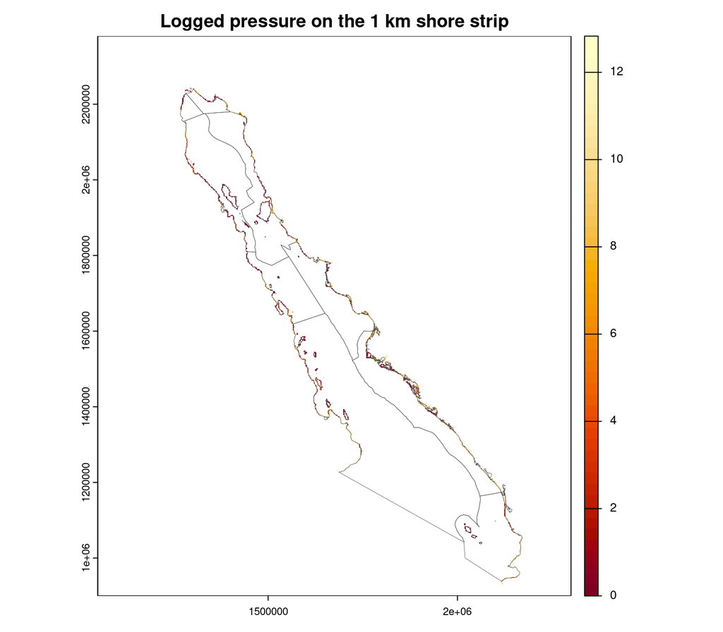

```r
plot(log_shore, main = "Logged pressure on the 1 km shore strip", col = hcl.colors(50, "YlOrRd"))
plot(st_geometry(regions %>% filter(location == "marine")), add = TRUE, border = "grey30", lwd = 0.4)
```

## 5. Scale from 0 to 1 using the Gulf shore

The reference is the 99.9th percentile of the logged values on this strip. A cell at that percentile scores 1. A cell at half of it scores 0.5. Cells above it are set to 1, so a few dense towns do not stretch the whole scale.

```r
shore_values <- values(log_shore, na.rm = TRUE)
stopifnot(length(shore_values) > 0)

ref_point <- as.numeric(quantile(shore_values, quantile_p))
stopifnot(ref_point > 0)

pressure <- ifel(log_shore > ref_point, 1, log_shore / ref_point)
pressure <- ifel(pressure < 0, 0, pressure)
names(pressure) <- "pressure"

n_at_one <- sum(values(pressure) == 1, na.rm = TRUE)

data.frame(
  quantile = quantile_p,
  reference_log_people = ref_point,
  reference_people_within_10km = exp(ref_point) - 1,
  shore_cells = length(shore_values),
  cells_at_one = n_at_one
)
```

```
##   quantile reference_log_people reference_people_within_10km shore_cells
## 1    0.999             12.80568                     364280.9       11019
##   cells_at_one
## 1           12
```

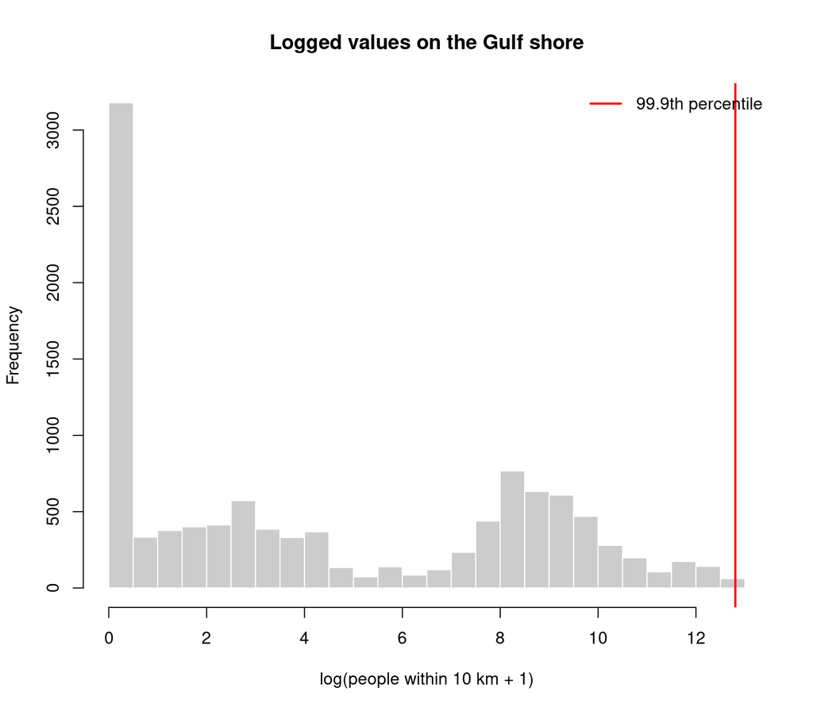

```r
hist(
  shore_values,
  breaks = 40,
  main = "Logged values on the Gulf shore",
  xlab = "log(people within 10 km + 1)",
  col = "grey80",
  border = "white"
)
abline(v = ref_point, col = "red", lwd = 2)
legend("topright", legend = "99.9th percentile", col = "red", lwd = 2, bty = "n")
```

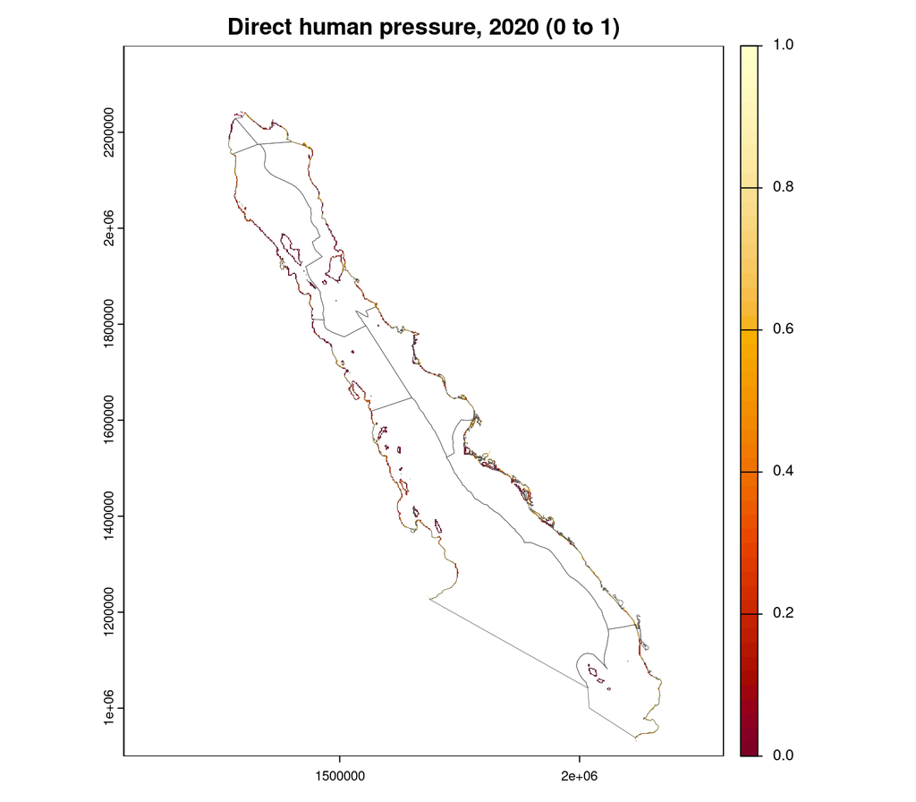

```r
map_path <- file.path(out_dir, "direct_human_2020_rescaled.tif")
writeRaster(pressure, map_path, overwrite = TRUE)

plot(pressure, main = "Direct human pressure, 2020 (0 to 1)", range = c(0, 1), col = hcl.colors(50, "YlOrRd"))
plot(st_geometry(regions %>% filter(location == "marine")), add = TRUE, border = "grey30", lwd = 0.4)
```

The map file is /home/frazier/ohi_goc_prep/_pressures/prs_population/output/direct_human_2020_rescaled.tif.

## 6. Average pressure in each region

Each shore cell already carries its region number. The regional pressure is the mean of the rescaled cells on that region’s shore, inland and offshore together.

```r
scores <- as.data.frame(c(region_r, pressure), na.rm = FALSE) %>%
  filter(!is.na(rgn_num), !is.na(pressure)) %>%
  group_by(rgn_num) %>%
  summarise(
    n_cells = n(),
    pressure = round(mean(pressure), 2),
    .groups = "drop"
  ) %>%
  mutate(
    rgn_id = paste0("Region_", rgn_num),
    year = year
  ) %>%
  arrange(rgn_num)

# The saved table matches the other pressure files: one row per region and year.
pressure_csv <- scores %>%
  select(rgn_id, year, pressure)

csv_path <- file.path(out_dir, "direct_human_pressure.csv")
write_csv(pressure_csv, csv_path)

kable(
  scores %>% select(rgn_id, year, n_cells, pressure),
  digits = 2,
  caption = "Mean rescaled pressure on the 1 km shore strip"
)
```

Mean rescaled pressure on the 1 km shore strip

| rgn_id | year | n_cells | pressure |
| --- | --- | --- | --- |
| Region_1 | 2020 | 216 | 0.29 |
| Region_2 | 2020 | 1500 | 0.14 |
| Region_3 | 2020 | 821 | 0.23 |
| Region_4 | 2020 | 2058 | 0.36 |
| Region_5 | 2020 | 343 | 0.29 |
| Region_6 | 2020 | 1423 | 0.28 |
| Region_7 | 2020 | 1168 | 0.46 |
| Region_8 | 2020 | 2563 | 0.45 |
| Region_9 | 2020 | 927 | 0.45 |

The table file is /home/frazier/ohi_goc_prep/_pressures/prs_population/output/direct_human_pressure.csv.